# Prepare stomach content data

```
pivot_longer: reorganized (FR_sad, FR_spr, FR_her) into (name, value) [was 9799x3, now 29397x2]
```

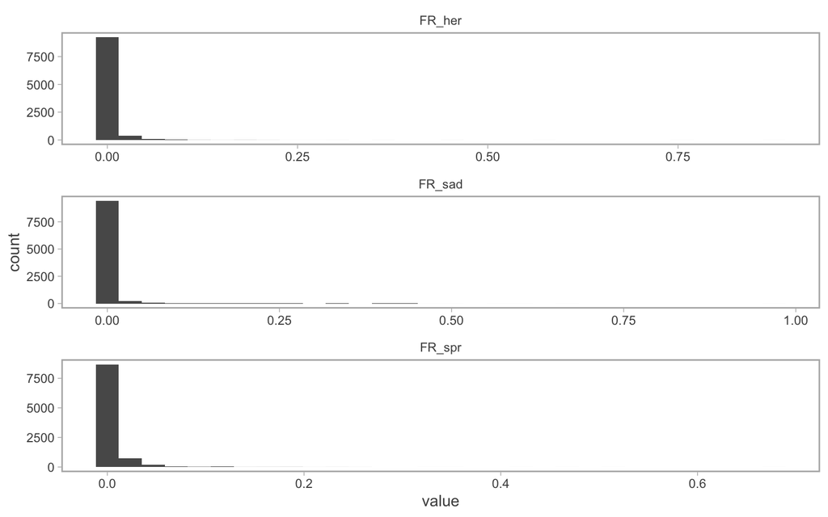

```r
dd2 |>
  dplyr::select(FR_sad, FR_spr, FR_her) |>
  pivot_longer(everything()) |>
  ggplot(aes(value)) +
  geom_histogram() +
  facet_wrap(~name, ncol = 1, scales = "free")
```

```r
dd %>%
  pivot_longer(c("herring", "saduria", "sprat")) |>
  group_by(name) |>
  summarise(prop_empty = sum(value == 0)/n(),
            prop_not_empty = sum(value != 0)/n())
```

```
pivot_longer: reorganized (saduria, sprat, herring) into (name, value) [was 10601x22, now 31803x21]
```

```
group_by: one grouping variable (name)
```

```
summarise: now 3 rows and 3 columns, ungrouped
```

```
# A tibble: 3 × 3
  name    prop_empty prop_not_empty
  <chr>        <dbl>          <dbl>
1 herring      0.885          0.115
2 saduria      0.851          0.149
3 sprat        0.758          0.242
```

Seems like fairly high proportions of cod without these key species in stomachs, but again, this is just from memory.

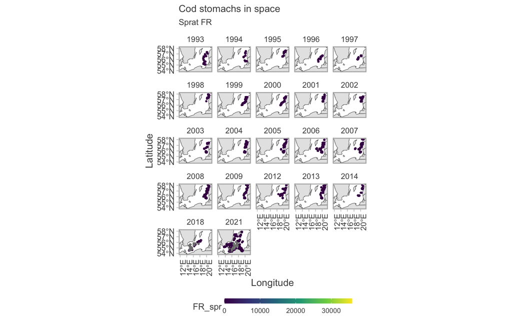

```r
# Inspect spatiotemporal resolution of feeding ratio
dd <- dd |> add_utm_columns(ll_names = c("lon", "lat"), utm_crs = 32633)

# This contains stuff from the loaded map plot script, I have a thing there for continues colors that make it crash here so I need to spell out the function minus that part
ggplot(swe_coast_proj) +
  xlim(xmin2, xmax2) +
  ylim(ymin2, ymax2) +
  labs(x = "Longitude", y = "Latitude") +
  geom_sf(size = 0.3) +
  theme_facet_map() +
  geom_point(data = dd, aes(X*1000, Y*1000, color = FR_spr), size = 0.5) +
  facet_wrap(~ year) +
  theme(legend.position = "bottom") +
  labs(title = "Cod stomachs in space", subtitle = "Sprat FR")
```

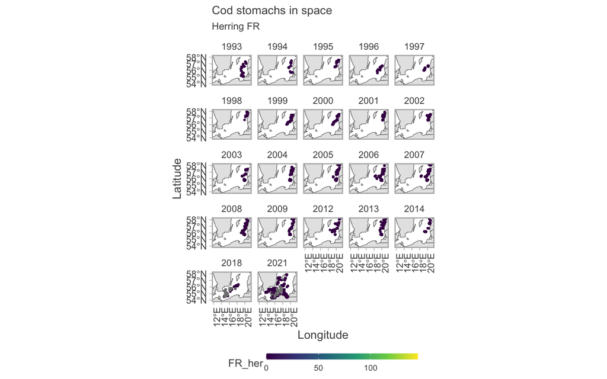

```r
ggplot(swe_coast_proj) +
  xlim(xmin2, xmax2) +
  ylim(ymin2, ymax2) +
  labs(x = "Longitude", y = "Latitude") +
  geom_sf(size = 0.3) +
  theme_facet_map() +
  geom_point(data = dd, aes(X*1000, Y*1000, color = FR_her), size = 0.5) +
  facet_wrap(~ year) +
  theme(legend.position = "bottom") +
  labs(title = "Cod stomachs in space", subtitle = "Herring FR")
```

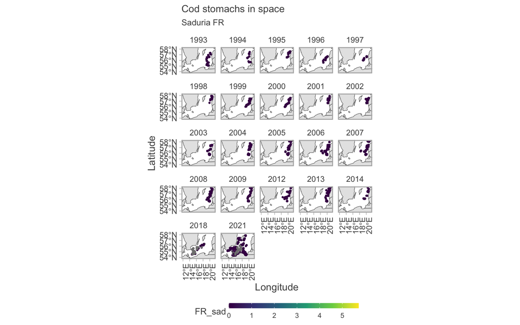

```r
ggplot(swe_coast_proj) +
  xlim(xmin2, xmax2) +
  ylim(ymin2, ymax2) +
  labs(x = "Longitude", y = "Latitude") +
  geom_sf(size = 0.3) +
  theme_facet_map() +
  geom_point(data = dd, aes(X*1000, Y*1000, color = FR_sad), size = 0.5) +
  facet_wrap(~ year) +
  theme(legend.position = "bottom") +
  labs(title = "Cod stomachs in space", subtitle = "Saduria FR")
```

**In summary**:

1) When are the rest of the data uploaded?

2) What do we do with the predator ID’s that are not matched across predator and prey files (both ways?).

3) How should we interpret weight 0? Treat it as NA weight?.

4) Do the proportions of cod stomachs without sprat, saduria or herring look reasonable?.

```r
# Save new data
write_csv(dd, paste0(home, "/data/clean/new_stomachs.csv"))
```